# Cyclistic User Differences

Last Updated: March 17, 2022

## Cyclistic Chicago

### Bike Share Program

- 2016 launch in Chicago, IL
- Bikes are unlocked from one station and returned to others
- More than 5,800 bicycles and 600 docking stations

[figure not shown]

### Single Ride (Casual Users)

- $3.30 per 30 minute use time
- $0.15/minute after 30 minutes
- 11.5 hour rental would cost about $108)

### Day Pass (Casual Users)

- $15 per 3 hours
- One day pass per 24 hours

## Differences between casual users and members?

### Annual Members are more profitable than casual members

#### Anallysis will give insight on:

- Targeted marketing toward casual users
  - Location: Where users use the service
  - Time:
    - Day of the week
    - Time of the day
    - Duration of trip
- Target casual members that use the service similar to annual members
  - Potential to lure these casual users
  - Hypothesize that casual users that use the service similar to annual members will be the best opportunity to convert to annual members.

## Cyclistic Chicago Data

### About Chicago

- 3rd most populous city in the United States
  - Pop. 2,746,388 in 2020 census
- 234 sq mi
- Diversified economy
  - hub for finance, commerce, transportation
- 58 million visitors a year

[figure not shown]

### Reliable

- - Data derived from [Cyclistic Internal Data](https://divvy-tripdata.s3.amazonaws.com/index.html)
  - [Data License Agreement](https://ride.divvybikes.com/data-license-agreement)

### Current

- - Last 12 months (March 2021 to February 2022)

### Secure

- - All identifying information has been removed

### Limitations:

- - Ride ID is not linked to specific users. Unknown if rides are independent or repeat users.

## Summary Statistics

### About the data

- Date Range: March 2021 - Feburary 2022
- Total observations, 5,667,986

### Calculated

- Month, day, hour of ride
- Duration of ride

### Inconsistencies

- Removed ride durations less than 1 minute
- Removed ride durations greater than 3 hours
  - ~4,000 trips greater than 12 hours
  - ~19,000 trips greater than 3 hours and less than 12 hours
- Some entries have missing docking station data
  - Use GPS data for location analysis

### Summary statistics of cleaned data

- mean duration
  - Casual users: 24.0 min
  - Annual members: 12.8 min
- median duration
  - Casual users: 15.8 min
  - Annual members: 9.5 min

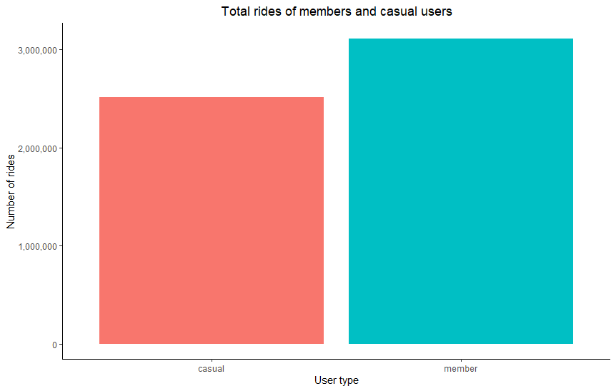

## Distribution is right-skewed and indicates short term rides are more favored

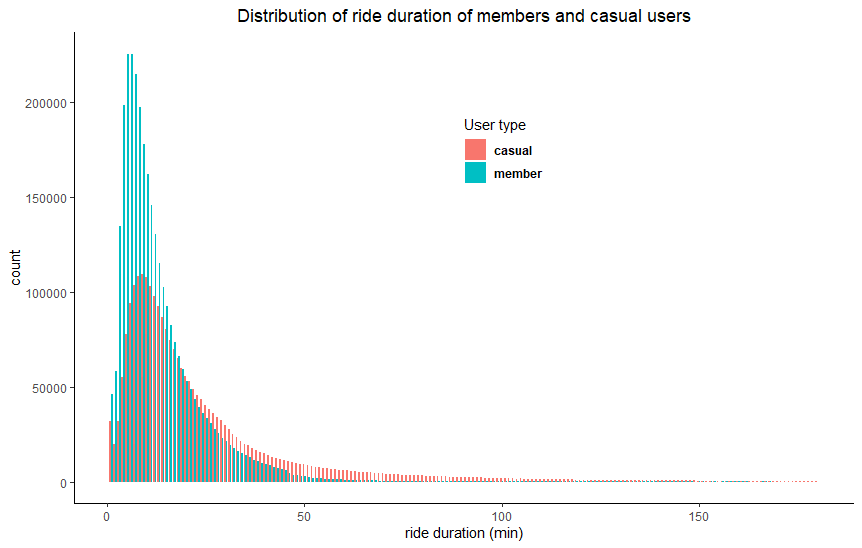

For statistical analysis the duration time will need to be transformed

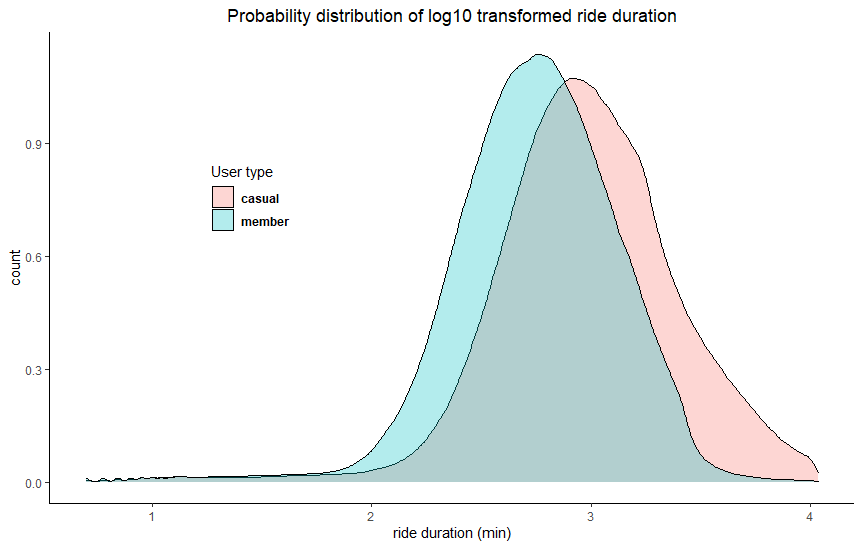

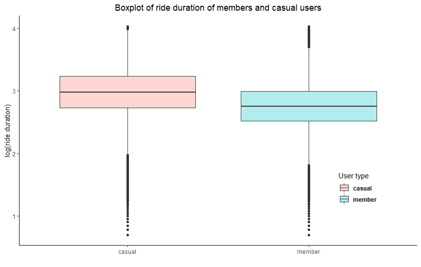

## Cycle rentals are highest in the summer months

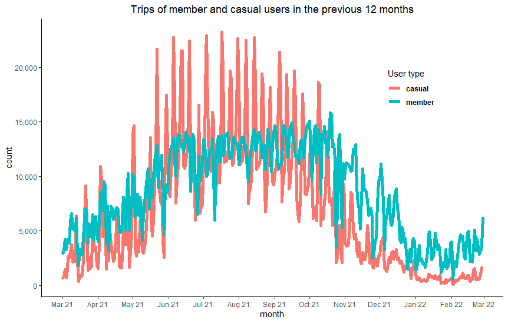

## Casual members outnumber annual members on the weekend

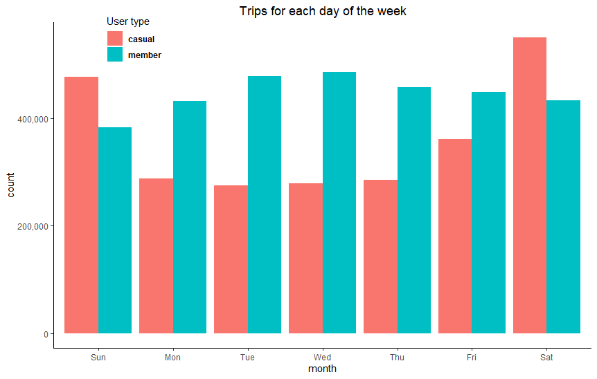

## Annual members outnumber casual members during daytime hours

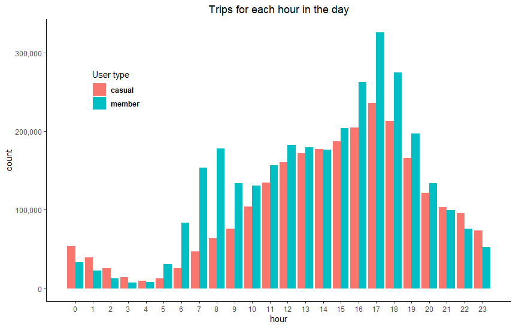

## Annual members are localized in business districts

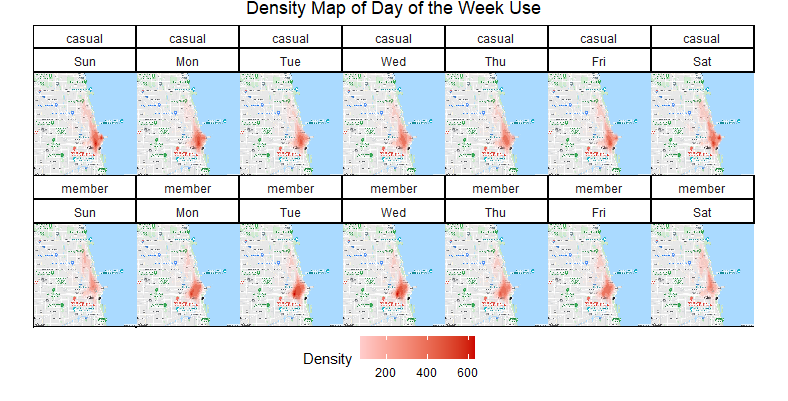

## Conclusions

### Summary

- Casual users outnumber annual members on the weekend
- Annual members outnumber casual users Monday through Friday.
- Annual member use spikes between 6:00 to 8:00 and 16:00 to 19:00. Traditional communing hours
- Annual members have highest density in the central business district
- Casual users have more spread out density with hot spots in recreational areas

### Recommendations

- Market to casual users that use the service similar to annual members
  - Remind casual users of annual membership benefits
  - Promote the savings when becoming an annual member
- Conduct user survey through the app and in-person
  - Identify how people are using the service (commute, recreation)
- Test surge pricing for casual users during commuting and positive weather